# Reproducible Research - Project 1

NK

Tuesday, May 12, 2015

The following document is a code for Project 1 of reproducible research. It describes an exploratory data analysis on a step counter data.

First set global options to always display code chunks:

```r
library(knitr)
opts_chunk$set(echo=TRUE)
```

## Loading and Preprocessing the Data

First, set the working directory (may be different for everyone)

```r
#Set working directory
setwd("C:\\Users\\N\\Dropbox\\Coursera\\05 - Reproducible Research\\RepData_PeerAssessment1")
```

Read accelerometer data that is located in the same folder

```r
#read in data
dat=read.csv(file="activity.csv",
             header=TRUE, sep=",",
             stringsAsFactors=FALSE,
             na.strings="NA")
dat$date=as.factor(dat$date)
```

**Calculate the total number of steps taken per day**

First extract the step data and the sum the steps via the aggregate function.

```r
#Take the step data and remove the NA values
mean_step_data=dat[!is.na(dat$steps),1:3]
#Calculate the sum
sum_steps=aggregate(mean_step_data[1],
                    by=list(mean_step_data$date),
                    FUN=sum)
sum_steps
```

```
##       Group.1 steps
## 1  2012-10-02   126
## 2  2012-10-03 11352
## 3  2012-10-04 12116
## 4  2012-10-05 13294
## 5  2012-10-06 15420
## 6  2012-10-07 11015
## 7  2012-10-09 12811
## 8  2012-10-10  9900
## 9  2012-10-11 10304
## 10 2012-10-12 17382
## 11 2012-10-13 12426
## 12 2012-10-14 15098
## 13 2012-10-15 10139
## 14 2012-10-16 15084
```

[output cut: 39 more lines]

**Create a histogram of the step summaries**

Create and show a histogram plot:

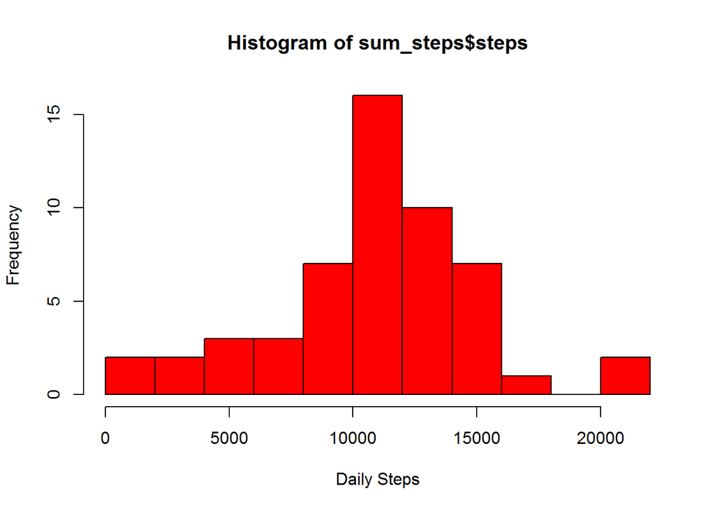

```r
#Make historgram
hist(sum_steps$steps,
     breaks=10,
     xlab="Daily Steps",
     col="red")
```

**Find the mean and median**

The median of the number of steps is:

```r
median(sum_steps$steps)
```

```
## [1] 10765
```

The mean number of steps is:

```r
mean(sum_steps$steps)
```

```
## [1] 10766.19
```

## What is the average daily activity pattern?

**Make a time series plot:**

Find the average interval number of steps:

```r
#interval data mean
id=aggregate(mean_step_data[1],by=list(mean_step_data$interval),FUN=mean)
```

Plot the mean interval data:

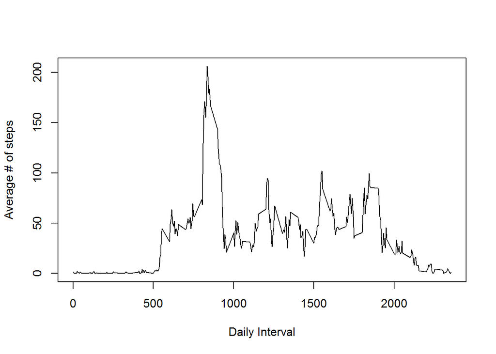

```r
plot(unique(mean_step_data$interval),
     id$steps,pch=16,
     type="l",
     xlab="Daily Interval",
     ylab="Average # of steps"
     )
```

**Find the Interval with maximum steps**

The values are stored in the id variable. Find the maximum index:

```r
which.max(id$steps)
```

```
## [1] 104
```

with a maximum value of

```r
max(id$steps)
```

```
## [1] 206.1698
```

## Imputing missing Values

**Find total missing entries**

First create a vector full of missing steps entries and then report its length

```r
#create empty vector indicator
na_vec=is.na(dat$steps)
#find total entires that are missing
sum(na_vec)
```

```
## [1] 2304
```

**Fill missing entries**

The code first appends a column full of means. The code then replaces the missing values with those means.

```r
#append means
dat$means<-ave(dat$steps,dat$date,rm.na=TRUE)
#remove NAs
dat[na_vec,"steps"]=dat[na_vec,"means"]
```

**Assign to new Tidy Data set**

label the tidy data set as tdat

```r
#find values that are still NA
still_na=is.na(dat$means)
#Assign tidy data set
tdat=dat[!still_na,]
#verify that there are no empties:
sum(is.na(tdat))
```

```
## [1] 0
```

**Make a histogram of the total number of steps**

Calculate sum and draw histogram:

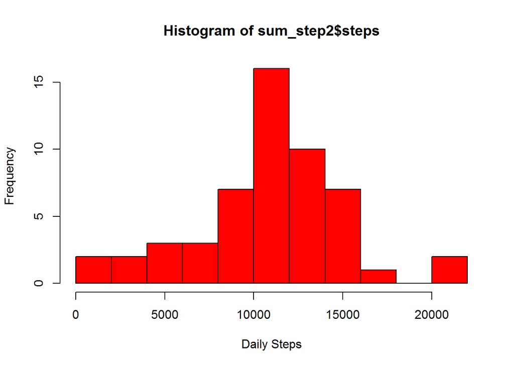

```r
#Calculate the sum
sum_step2=aggregate(tdat[1],
                    by=list(tdat$date),
                    FUN=sum)
#Make histogram
hist(sum_step2$steps,
     breaks=10,
     xlab="Daily Steps",
     col="red")
```

The median of the tidy number of steps is:

```r
median(sum_step2$steps)
```

```
## [1] 10765
```

The mean tudy number of steps is:

```r
mean(sum_step2$steps)
```

```
## [1] 10766.19
```

The mean and median has not changed by replacing NA values with the mean step values.

## Difference in Activity Patterns between Weekends and Weekdays

**Separate data into wekedays**

The following code first appends a weekdays variable. Then the code appends a variable that states whether the day is a weekend or a weekday.

```r
#change factors to characters
tdat$date<-lapply(tdat[,"date"],as.character)
#change char to date
library("lubridate")
tdat$date<-ymd(tdat$date)
tdat$weekdays<-weekdays(tdat$date)
tdat$isWeekend<-tdat$weekdays %in% c('Saturday','Sunday')
```

**Determine patterns in Intervals and Weekdays**

First prepare the interval data (id) to properly rename the variables and calculate the means

```r
#Calculate means and rename variables and prepare values for plotting
id=aggregate(tdat[,1],by=list(tdat$interval,tdat$isWeekend),FUN=mean)
#rename variables
library(plyr)
id=rename(id,c("Group.1"="interval", "Group.2"="isWeekend","x"="steps"))
id$isWeekend<-as.factor(ifelse(id$isWeekend, "weekend", "weekday"))
```

Now run some plotting code to reproduce the graph usign the lattice plot function:

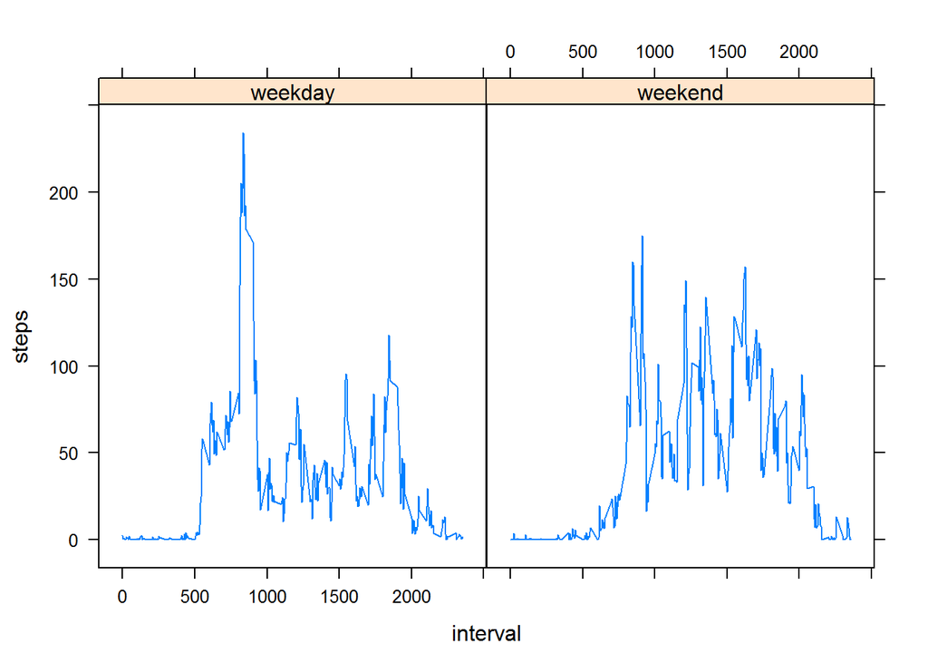

```r
#Plot
library(lattice)
xyplot(steps~interval| isWeekend, data=id,type="l")
```

There is a clear difference in the shapes of the weekeday steps and the weekend step patterns. There are more steps in the weekend and the peak of the weekdays occurs a early in the interval.